# Ventas de Degas en Christie’s

José Blanco Perales

## Ventas entre 2007 y 2018

### Datos generales

#### Distribución de los precios

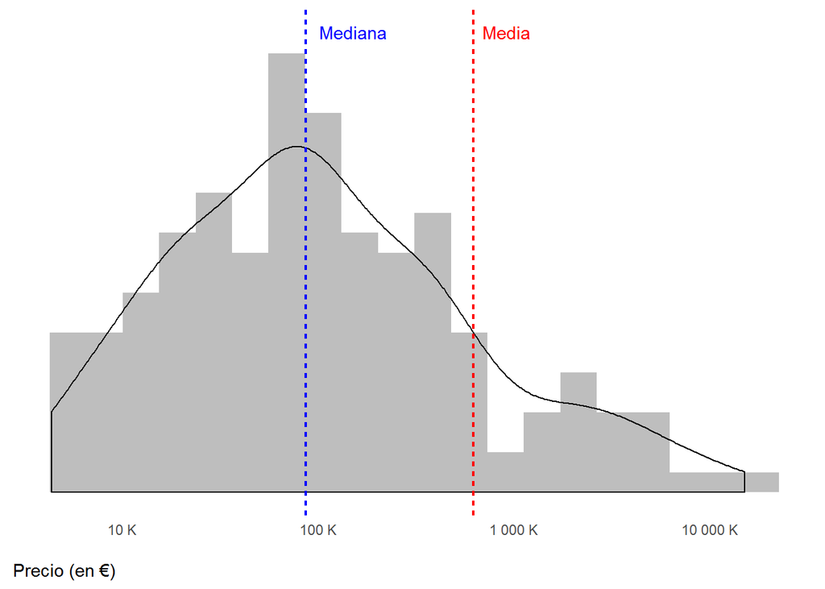

#### Número de obras vendidas y suma de los precios por año

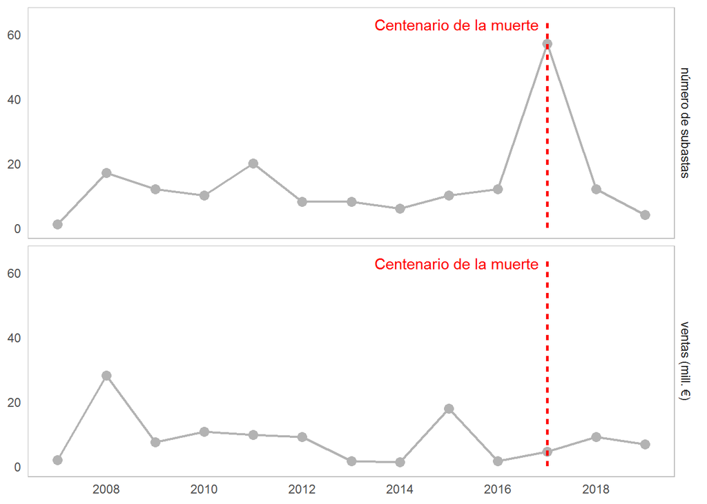

#### % de las ventas de las obras de Degas en cada subasta

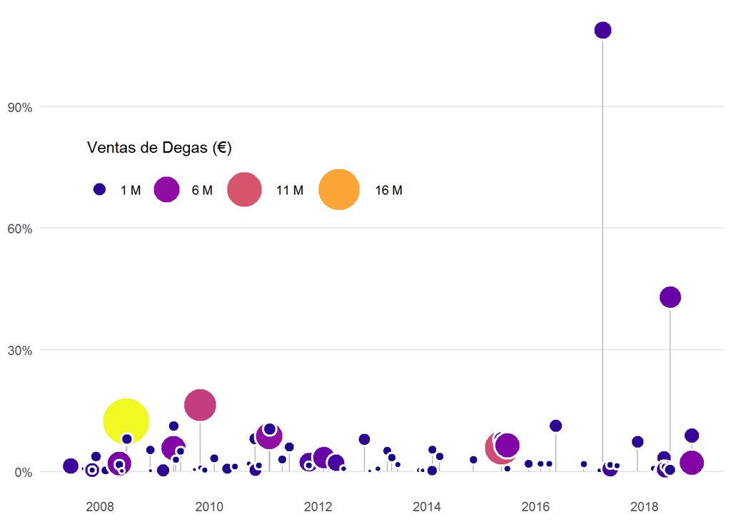

### Por categorías

#### Técnica

##### Distribución del precio de las obras según la técnica

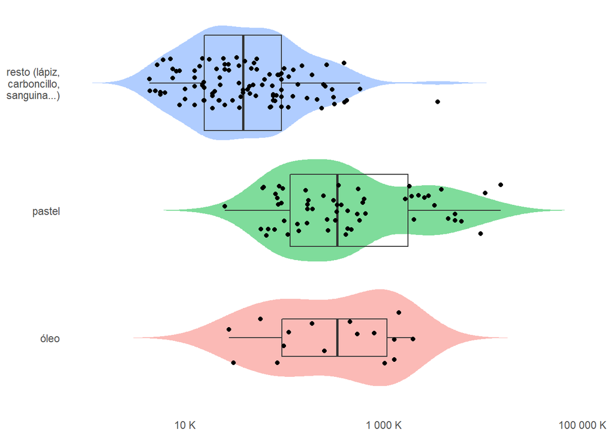

##### Distribución de los tamaños de las obras según la técnica

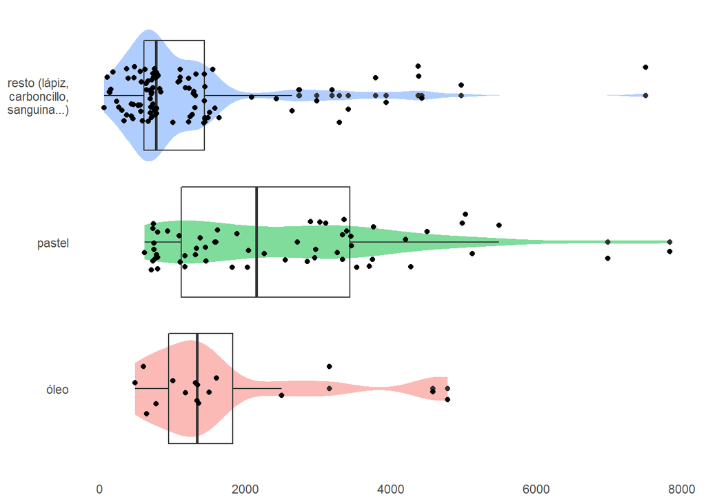

##### Número de lotes y ventas por año según a técnica

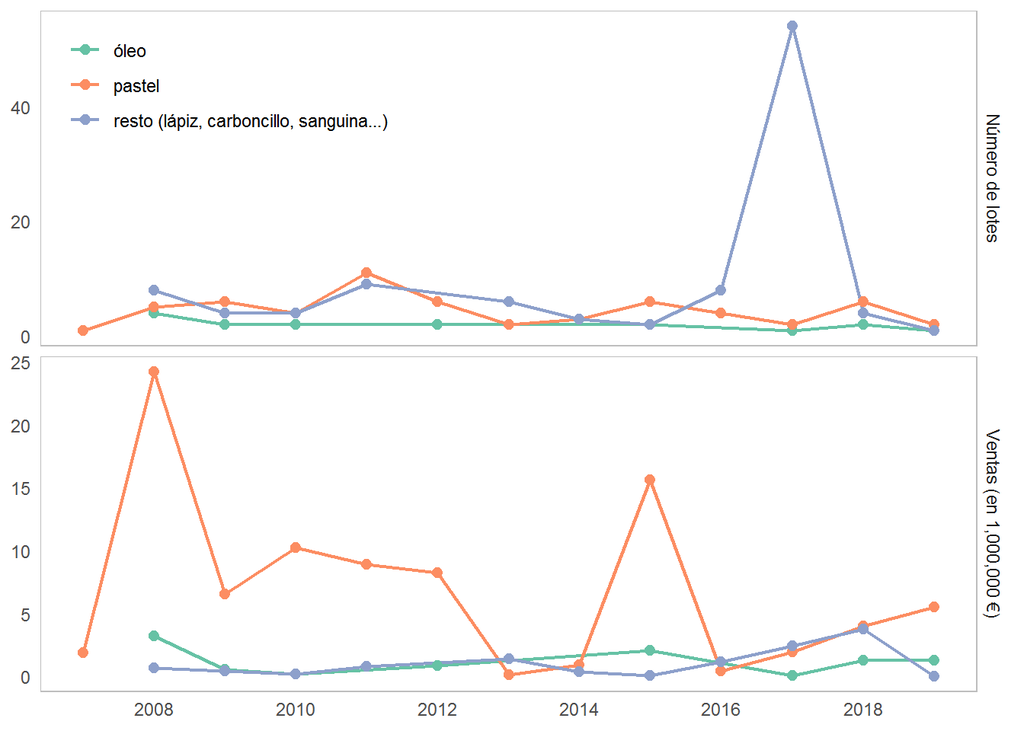

#### Sede

##### Distribución del precio de las obras según la sede

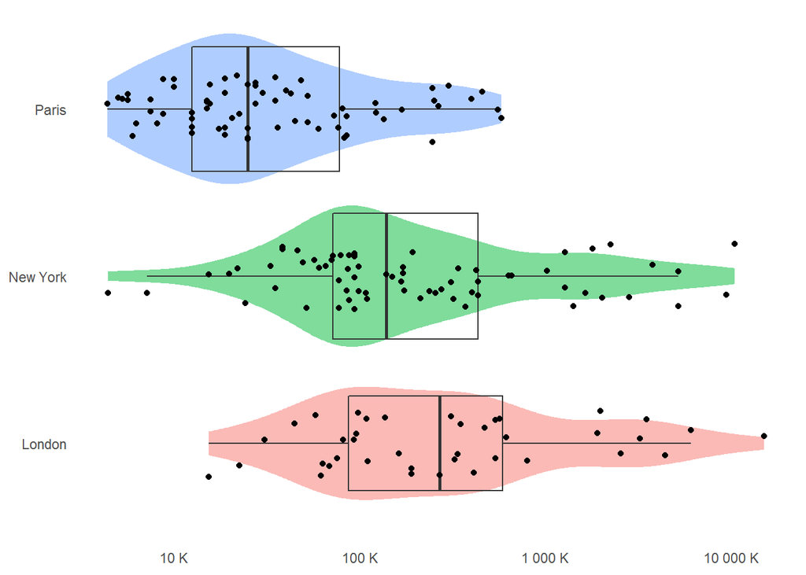

##### Número de obras y ventas totales según la sede

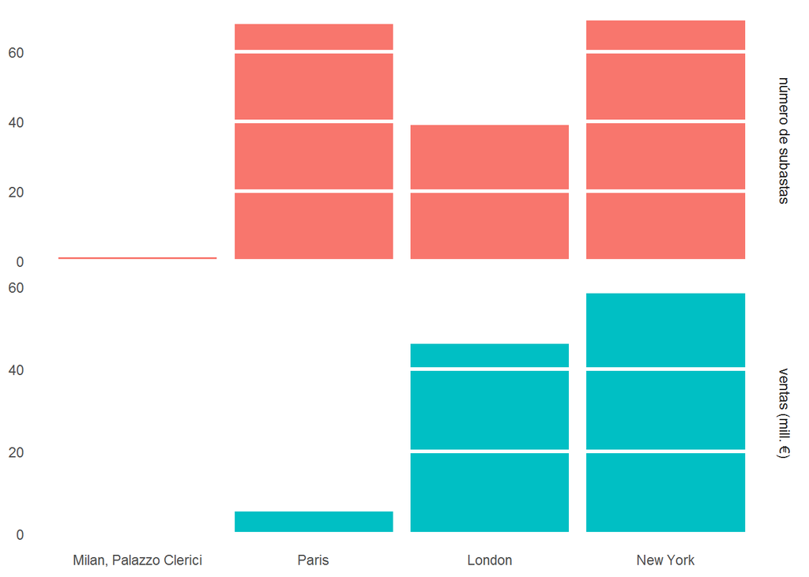

##### Número de lotes y ventas por año según la sede

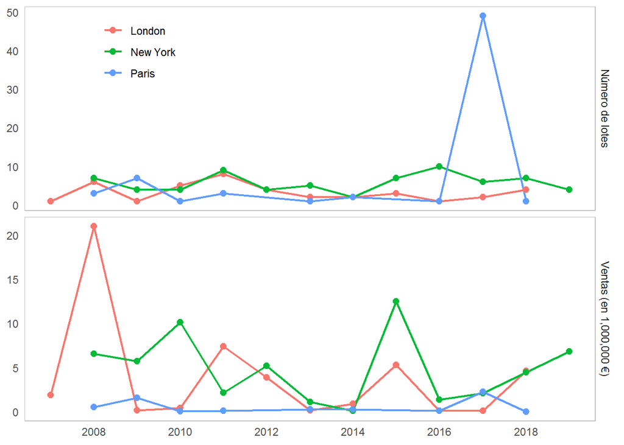

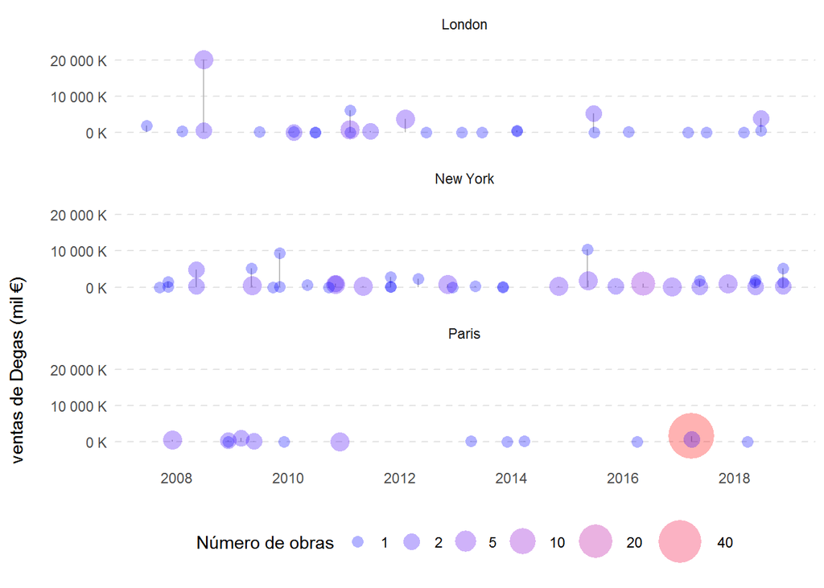

##### Número de piezas vendidas por mes en cada sede

Se ha omitido la única subasta de Milán y la subasta de París del 23 de marzo de 2017 en la que se vendieron muchas más piezas de las que se suelen vender de Degas.

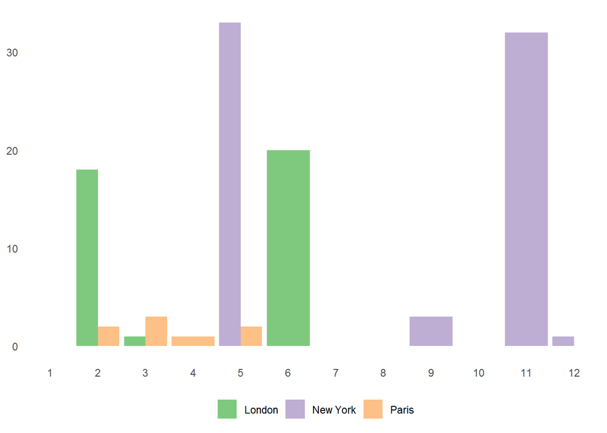

#### Estimaciones

##### Frecuencia de los tipos de estiamción

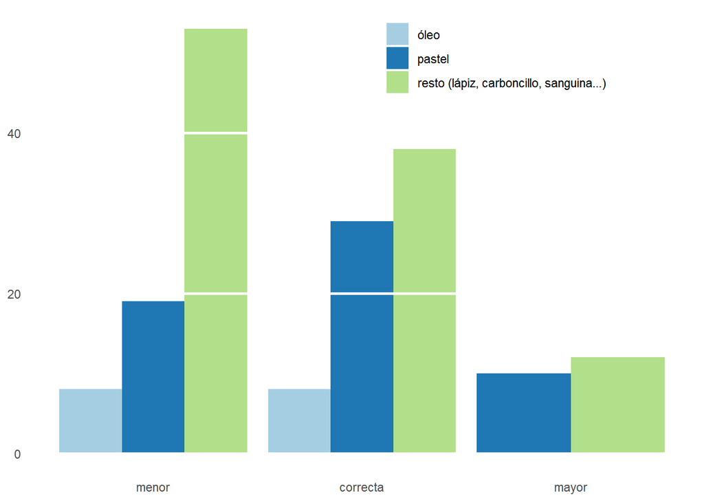

##### Distribución de los tipos de estimación

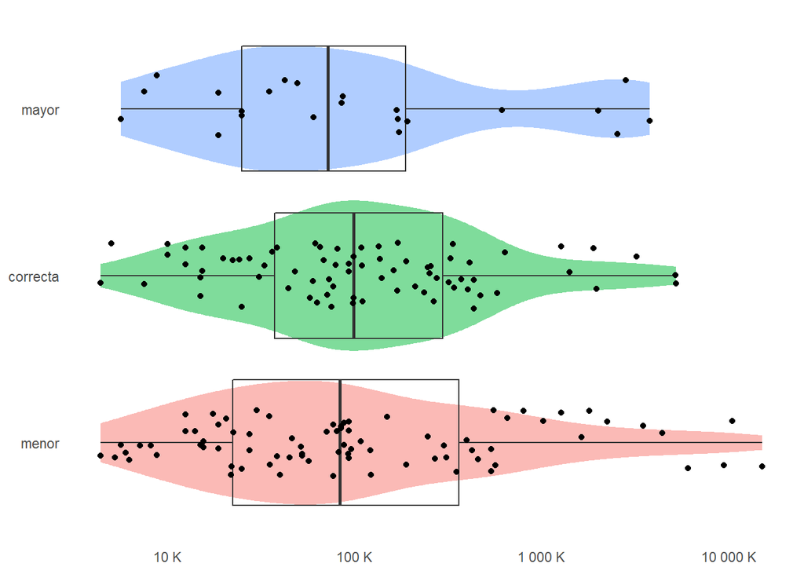

##### Porcentaje de la diferencia entre la estimación y el precio final

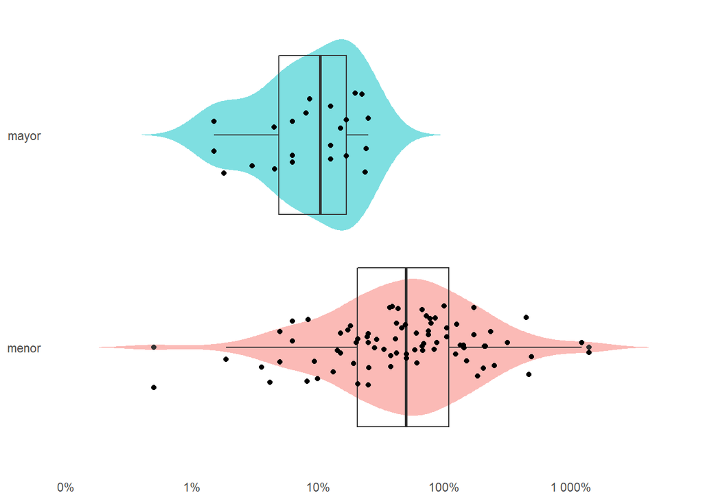

##### Evoluciones de las estimaciones por año

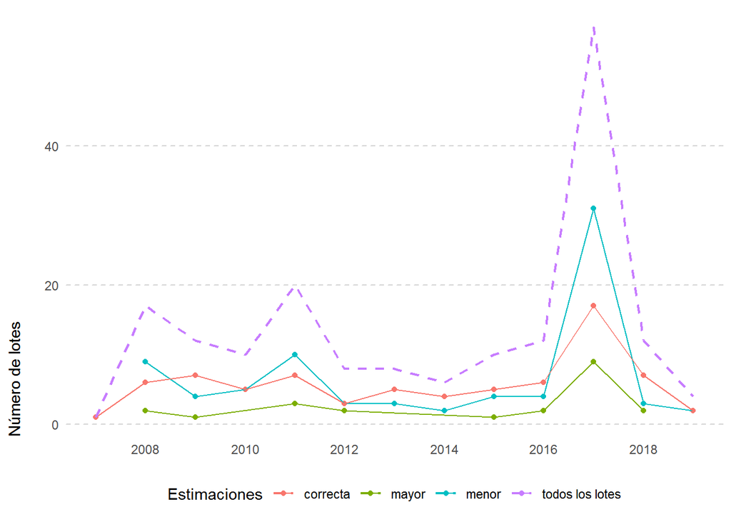

#### Firma

##### Distribución del precio final según el tipo de firma

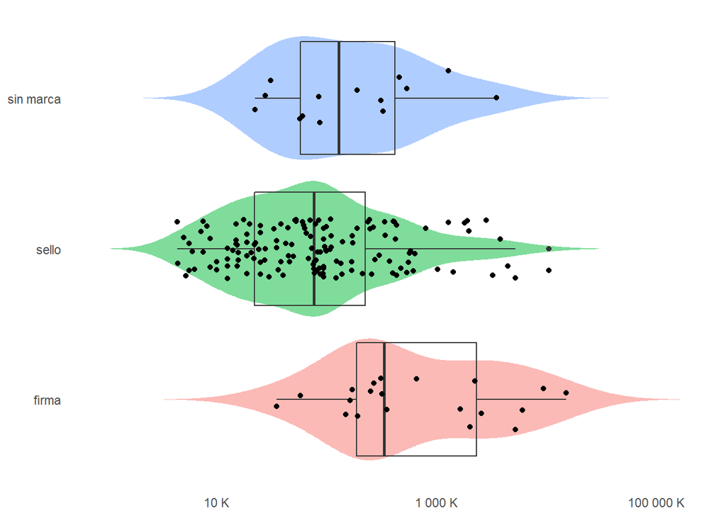

##### Frecuencia de las técnicas según el tipo de firma

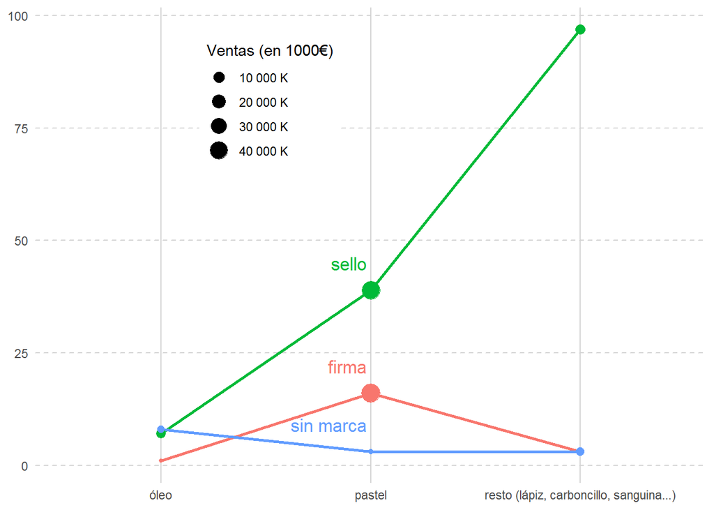

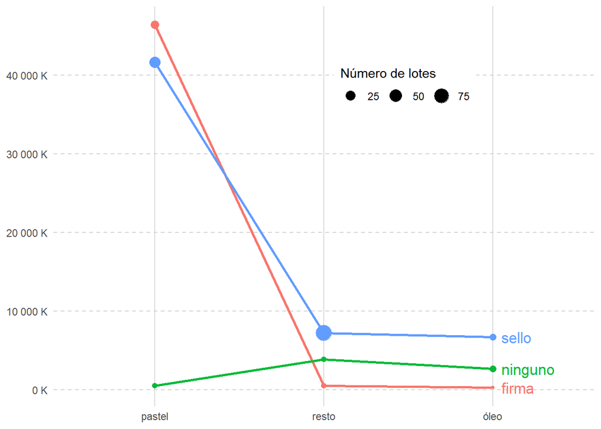

#### Fecha de producción

##### Ventas y número de obras según fecha de producción

Las obras se agrupan en periodos de 5 años. El tamaño muestra la cantidad de obras vendidas. Las obras sin fecha de producción se muestran en la posición ‘0’.

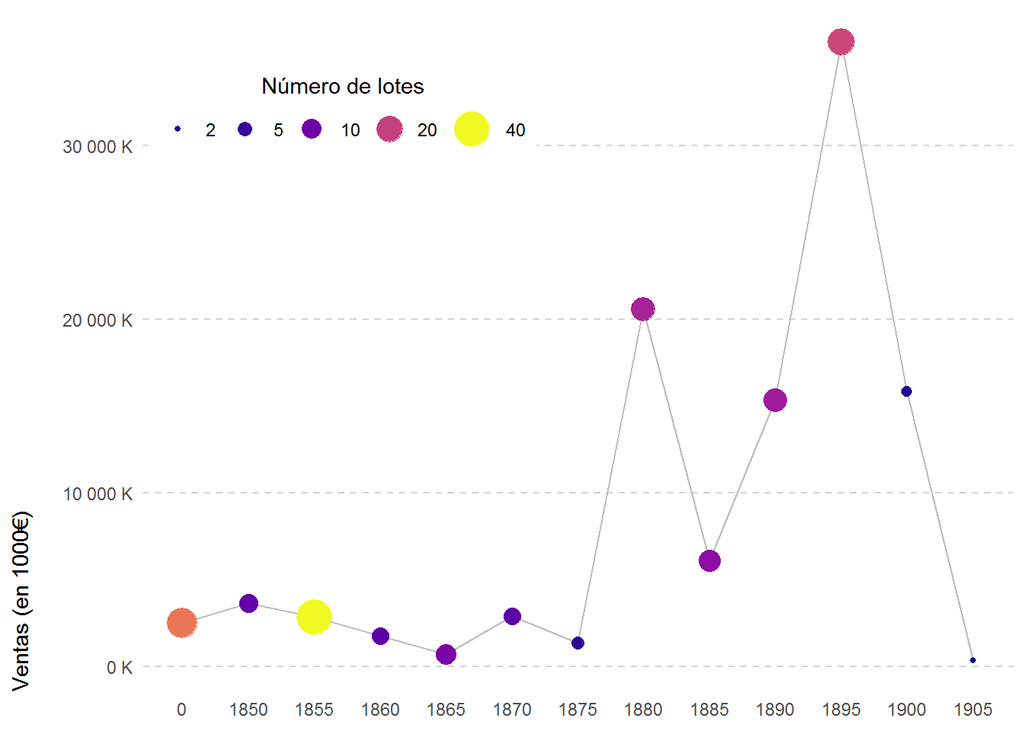

##### Ventas de las obras de Degas según la fecha de producción y el tema

Las obras se agrupan en periodos de 5 años y las facetas están ordenadas por número de lotes según el tema. El tamaño muestra la cantidad de obras vendidas. Las obras sin fecha de producción se muestran en la posición ‘0’.

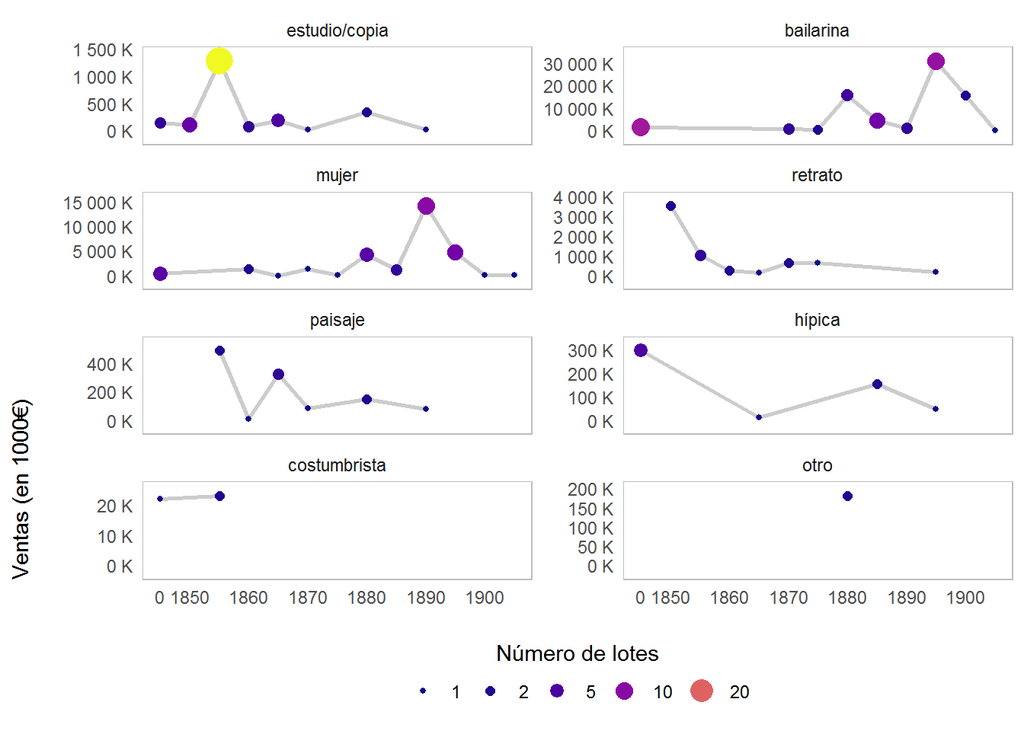

##### Ventas de las obras de Degas según la firma la fecha de producción

Las obras se agrupan en periodos de 5 años. El tamaño muestra la cantidad de obras vendidas. Las obras sin fecha de producción se muestran en la posición ‘0’.

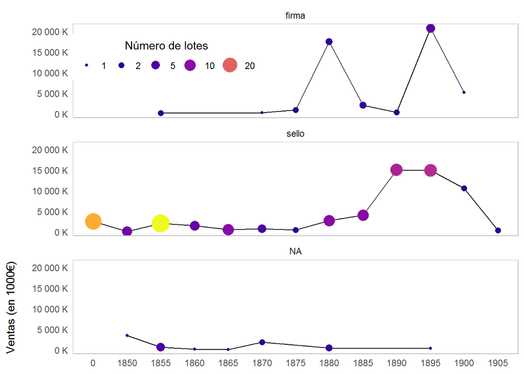

#### Tema

##### Número de lotes y ventas por tema y técnica

[figure not shown]

##### Ventas de óleos y dibujos por tema

Ordenado por ventas totales en ambas técnicas.

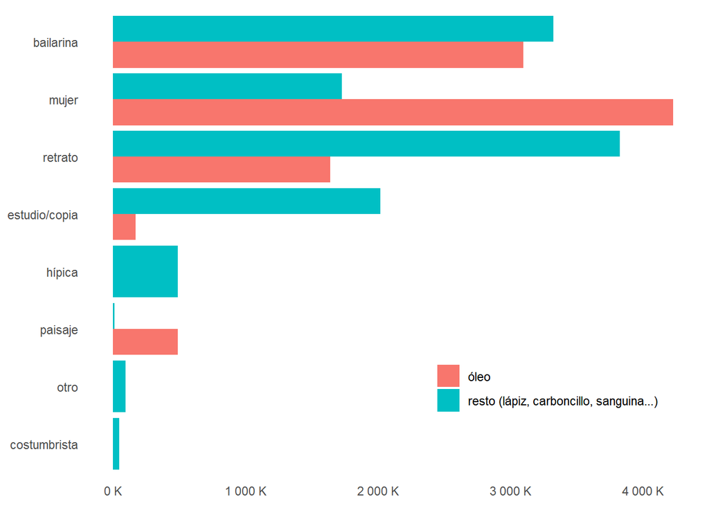

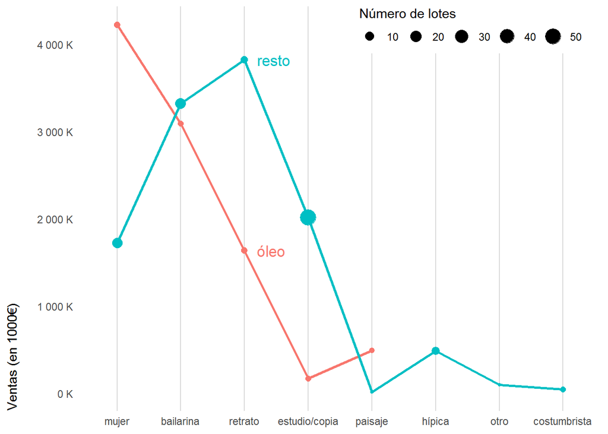

### Relaciones

#### Relación entre el tamaño de la obra y su precio según la técnica

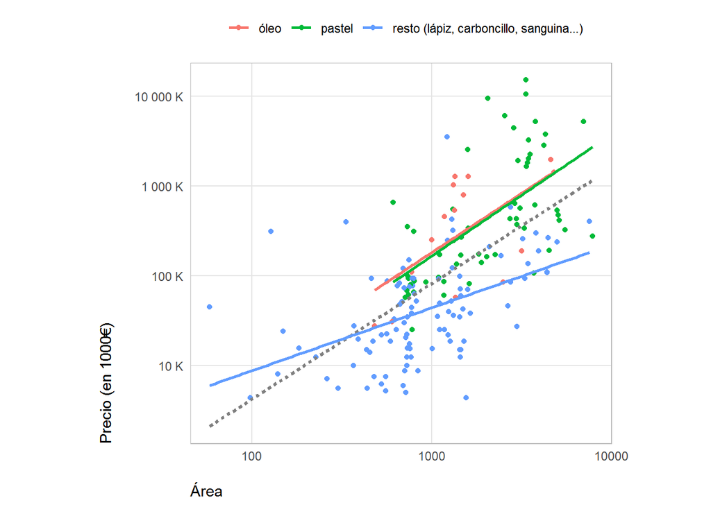

#### Relación entre el precio final y la diferencia con la estimación.

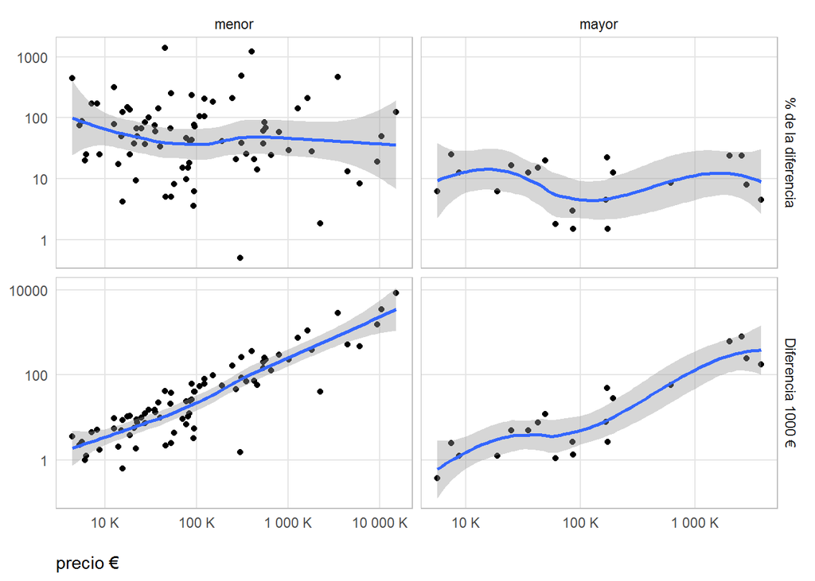

#### Relación entre el precio y la fecha de producción

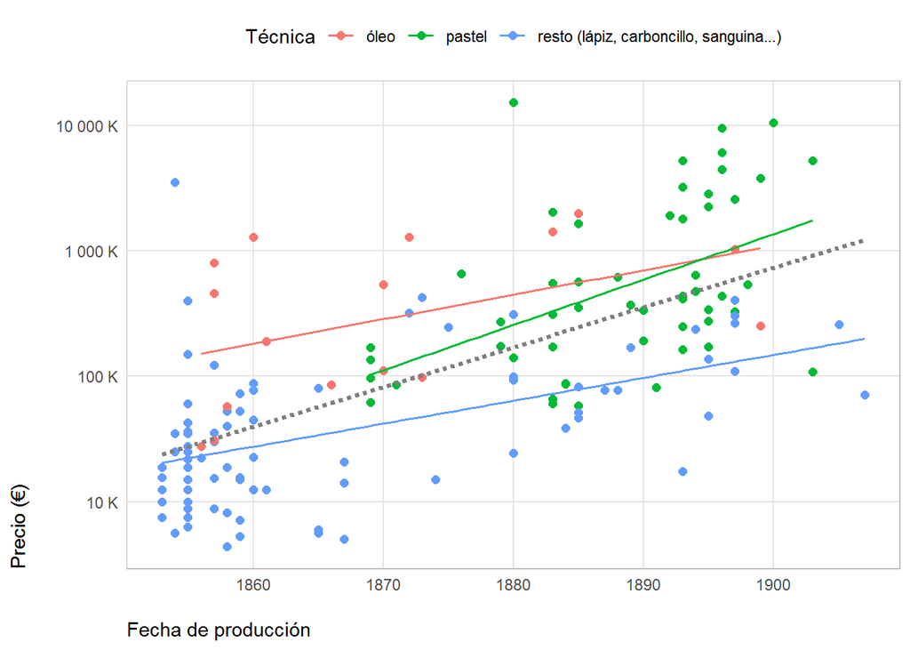

#### Relación entre el precio de venta, la fecha de producción y la de venta

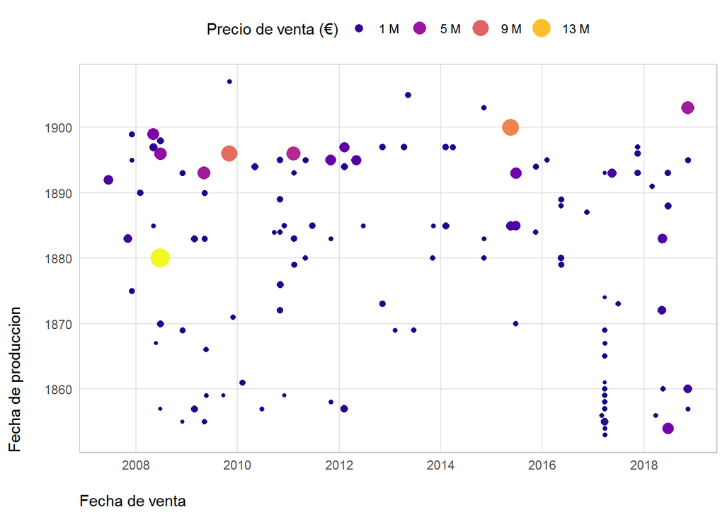

#### Relación entre la fecha de producción, el tema, la técnica y el tipo de firma

No incluye las obras cuya fecha de producción es desconocida.

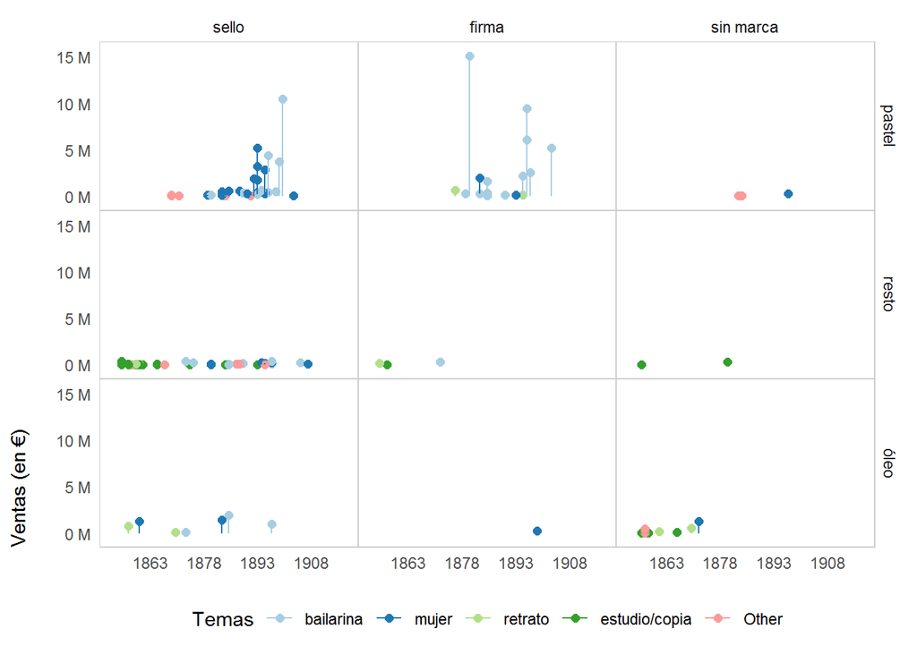

Esta obra está bajo una [Licencia Creative Commons Atribución-NoComercial 4.0 Internacional](http://creativecommons.org/licenses/by-nc/4.0/).